**Autor:** Luis Alberto Solis Peña

**Fecha última revisión:** 2024-04-23

## OBJETO DEL INDICADOR

Representa la comparación del activo de la institución respecto al resultado obtenidos en un intervalo de tiempo, es decir, el indicador busca cuantificar o exponer la capacidad de generar retornos de la institución con los recursos que dispone.

## MARCO TEÓRICO

Si entendemos a las finanzas, bajo el concepto expuesto por J. Gitman and J. Zutter (2012) como “El arte y la ciencia de administrar el dinero”, donde los indicadores, ratios, cocientes o índices expresadas como medidas aritméticas establecen una relación cuantitativa entre dos o más partidas de los estados financieros:

- Balance general
- Estado de resultados
- Estados financieros complementarios

Ahora bien, la ecuación o formula del ROA se compone de:

$$ROA = \frac{ \text{Resultado Neto} }{
\text{Total Activo} }$$

Donde, las variables que componen esta expresión son extraídos bajo el siguiente criterio:

- El resultado neto es una cuenta del estado de resultados.
- El total activo es una cuenta del balance general.

## CRITERIO DE DECISIÓN

Teniendo como criterio objetivo la de maximizar los retornos obtenidos:

Se considera como escenario o institución más favorable al que posea un ROA más elevado, es decir, manteniendo constantes otras variables exógenas se elegirá el proyecto, alternativa o empresa con mayor rendimiento sobre activos (ROA).

## PRACTICA

Se presenta dos alternativas, la empresa “A” y “B” de los cuales se tiene el activo y resultado neto contabilizado para las siguientes gestiones:

| GESTION | ENTIDADES | ACTIVO | RESULTADO NETO DE GESTION |
| --- | --- | --- | --- |
| 2020 | EMPRESA A | 25192 | 876.6816 |
| 2021 | EMPRESA A | 32858 | 1153.3158 |
| 2022 | EMPRESA A | 35382 | 1309.1340 |
| 2023 | EMPRESA A | 33435 | 1019.7675 |
| 2024 | EMPRESA A | 26806 | 927.4876 |
| 2020 | EMPRESA B | 4363 | 249.5636 |
| 2021 | EMPRESA B | 3480 | 207.7560 |
| 2022 | EMPRESA B | 2174 | 115.4394 |
| 2023 | EMPRESA B | 2053 | 105.5242 |
| 2024 | EMPRESA B | 3083 | 155.0749 |

En primer término, se visualiza la evolución de activos y resultado neto para las entidades correspondientes:

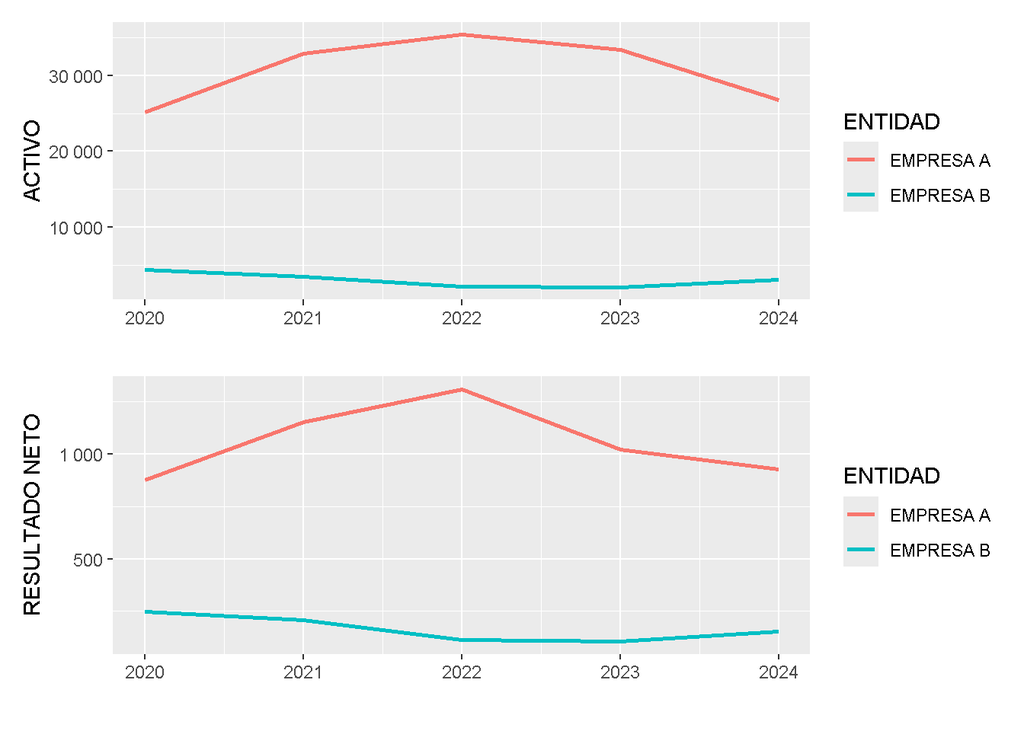

Se observa que la empresa “A” en términos monetarios posee mayor activo y resultado neto por periodo, pero aplicando el indicador ROA se obtiene:

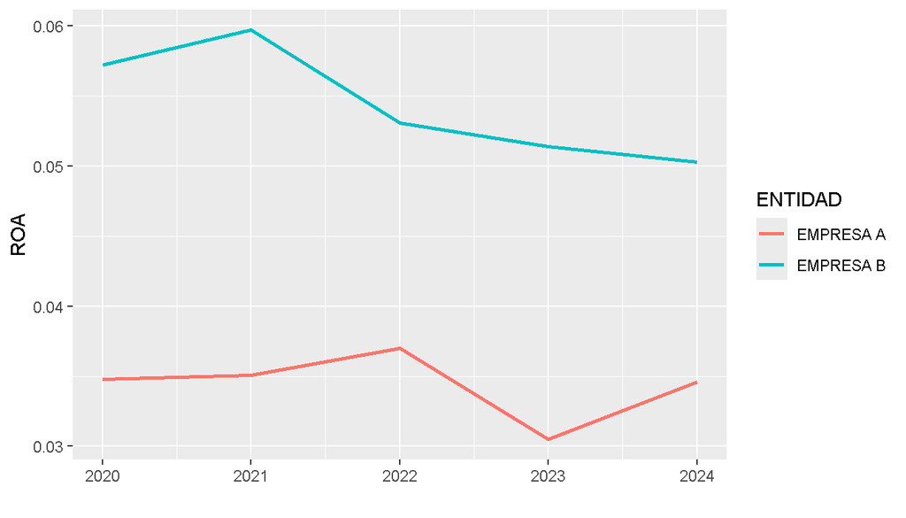

Resumiendo, estos resultados se tienen:

[output not shown]

Donde bajo el criterio de decisión expuesto anteriormente, si bien la empresa “A” posee un mayor activo y resultado neto de gestión contabilizado, se concluye que manteniendo constantes otras variables exógenas la empresa “B” es la alternativa que genera mayores retornos sobre los recursos que administra.

## REFERENCIAS

J. Gitman, Lawrence, and Chad J. Zutter. 2012. *Principios de Administración Financiera*. México, S.A. de C.V.: Pearson Educación S.A.